# Machine Learning Project: Spotify Song Clustering

## Problem Statement

Spotify, a leading audio streaming service with over 456 million monthly active users, aims to enhance song recommendations by creating cohorts of similar songs based on relevant features. As a data scientist, your task is to perform exploratory data analysis and cluster analysis on a dataset containing information about Rolling Stones albums available on Spotify.

## Objective

Conduct exploratory data analysis and cluster analysis to create cohorts of songs, gaining insights into the factors that contribute to song similarity.

## Dataset

The dataset contains information from Spotify's API about all Rolling Stones albums available on the platform. Each song has a unique ID.

## Project Steps

### 1. Initial Data Inspection and Cleaning

- Examine the data for:
  - Duplicates
  - Missing values
  - Irrelevant entries
  - Outliers
  - Erroneous entries
- Rectify issues as needed

### 2. Data Refinement

Refine the dataset based on findings from the initial inspection.

### 3. Exploratory Data Analysis and Feature Engineering

#### a. Album Recommendations

Use visualizations to identify the two albums with the most popular songs for general recommendations.

#### b. Feature Analysis

Conduct exploratory data analysis to identify patterns in various song features.

#### c. Popularity Correlation

Examine the relationship between song popularity and various factors, analyzing how this correlation has evolved over time.

#### d. Dimensionality Reduction

Provide insights on the importance of dimensionality reduction techniques and share observations.

### 4. Cluster Analysis

#### a. Optimal Cluster Number

Identify the appropriate number of clusters for the dataset.

#### b. Clustering Algorithms

Apply suitable clustering algorithms to group similar songs.

#### c. Cluster Definition

Define each cluster based on the features of the songs it contains.

## Deliverables

1. Cleaned and refined dataset
2. Exploratory Data Analysis report with visualizations
3. Cluster analysis results and interpretations
4. Final presentation summarizing findings and recommendations

By completing this project, you will gain valuable experience in data analysis, feature engineering, and clustering techniques while contributing to Spotify's goal of improving song recommendations.

### Author: Omar Nur

## Abstract

This study explores the creation of cohorts of songs based on various audio features using machine learning techniques. The study aims to identify patterns and groupings within a dataset of songs, potentially uncovering insights into musical preferences and genre classifications.

## Executive Summary

The project analyzes a dataset of songs using K-means clustering to create cohorts based on audio features. The process involves data preprocessing, feature selection, and the application of unsupervised learning techniques. The resulting clusters provide insights into song similarities and potential genre classifications.

## Model Accuracy and Measures

As K-means clustering is an unsupervised learning technique, traditional accuracy measures are not applicable. However, the model's performance can be evaluated using metrics such as inertia (within-cluster sum of squares) and silhouette score.

## Model Reliability

The reliability of the model depends on several factors:

1. **Feature Selection**: The chosen audio features should adequately represent the characteristics of the songs.
2. **Number of Clusters**: The optimal number of clusters was determined using the elbow method, which helps in finding a balance between model complexity and performance.
3. **Reproducibility**: The K-means algorithm was initialized multiple times to ensure consistent results.

## Recommendations

1. **Genre Classification**: Use the created cohorts as a basis for developing a genre classification system.
2. **Playlist Generation**: Leverage the clustering results to create personalized playlists or recommend similar songs to users.
3. **Feature Importance**: Analyze the importance of different audio features in determining song similarities.

## Further Study

1. **Alternative Clustering Algorithms**: Explore other clustering techniques such as hierarchical clustering or DBSCAN to compare results.
2. **Temporal Analysis**: Investigate how song cohorts change over time by incorporating release date information.
3. **Lyrical Analysis**: Integrate natural language processing techniques to analyze song lyrics alongside audio features.
4. **User Preferences**: Combine clustering results with user listening data to improve music recommendation systems.

### 1. To start our analysis, we'll import the required Python libraries and load our dataset.

1. Import necessary libraries:
   - pandas and numpy for data manipulation
   - matplotlib and seaborn for data visualization
   - sklearn for machine learning tasks (preprocessing, PCA, clustering)
   - scipy for statistical analysis
2. Load the data:
   - Reads a CSV file named 'rolling_stones_spotify.csv' into a pandas DataFrame called 'df'

The code prepares the workspace for analyzing the Rolling Stones Spotify dataset, enabling tasks such as data exploration, visualization, preprocessing, dimensionality reduction, clustering, and statistical analysis

```python
df.head(5)
```

[output not shown]

5 rows × 23 columns

### Now, let's go through each step:

Initial data inspection and data cleaning:

```python
df = df.drop(['Unnamed: 0'],axis=1)
```

```python
df.shape
```

[output not shown]

```python
# Check for duplicates
print("Duplicate rows:", df.duplicated().sum())
```

```
Duplicate rows: 0
```

```python
# Check for missing values
print("Missing values:\n", df.isnull().sum())
```

[output not shown]

```python
# Check data types
print(df.info())
```

[output not shown]

The above output provides a summary of the DataFrame structure and content. Here's a clear explanation:

This summary helps us understand the size, structure, and data types of our dataset, which is crucial for planning our analysis and choosing appropriate methods for data processing and modeling.

```python
### Perform Descriptive statistics
print(df.describe())
```

[output not shown]

After preprocessing and analysis, the above output provides a statistical summary of the dataset. Here's an explanation of the key points:

Our summary provides insights into the distribution of various features in the dataset, helping to understand the characteristics of the Rolling Stones songs and the results of the clustering analysis performed.

```python
# Remove duplicates if any
df = df.drop_duplicates()
```

```python
# Handle missing values (if any)
df = df.dropna()
```

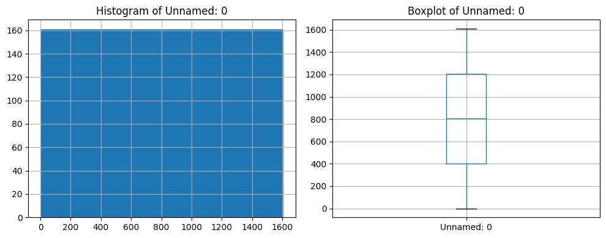

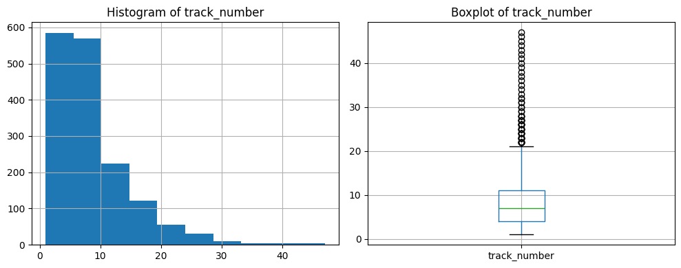

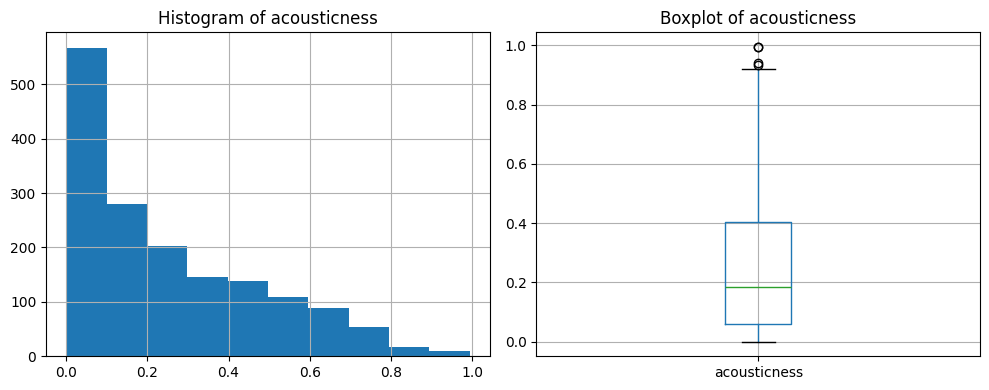

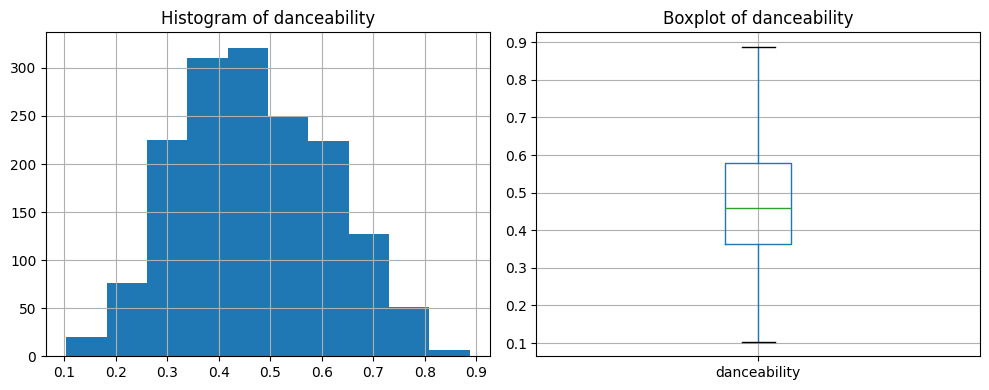

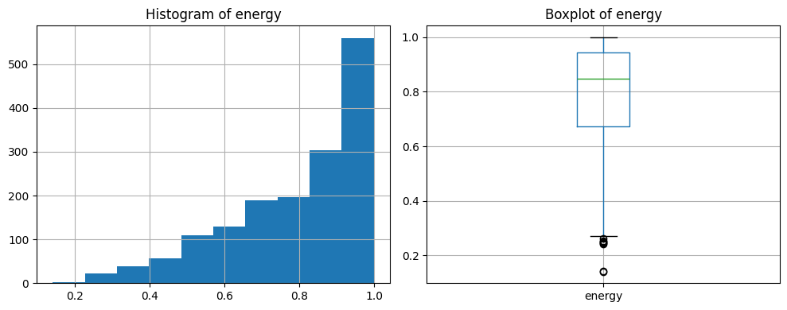

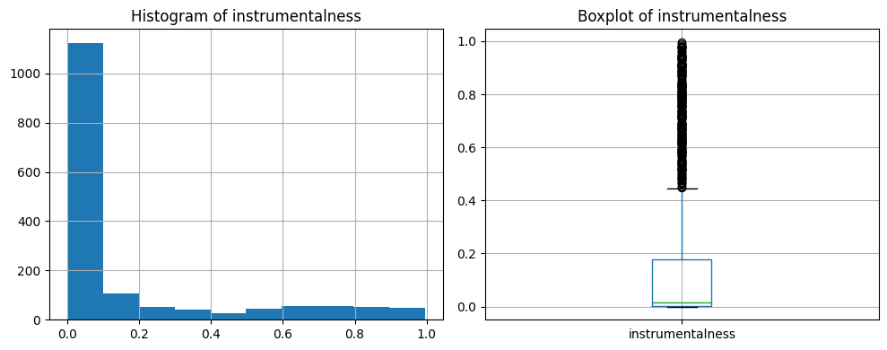

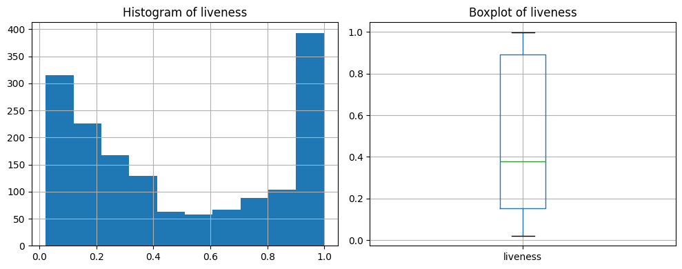

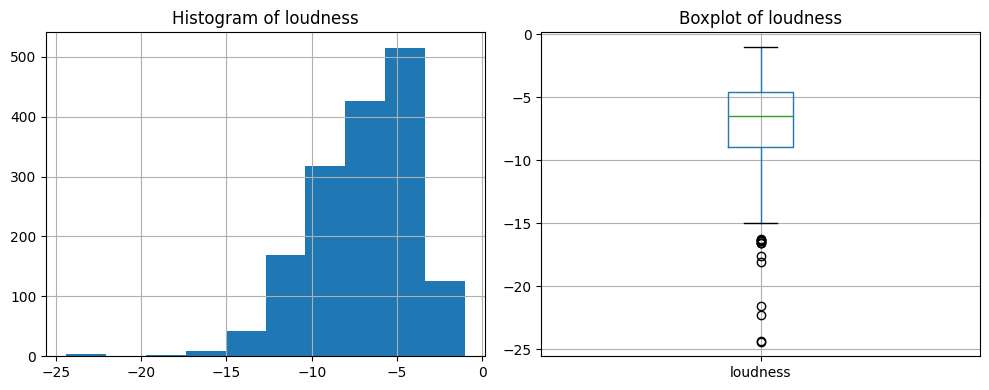

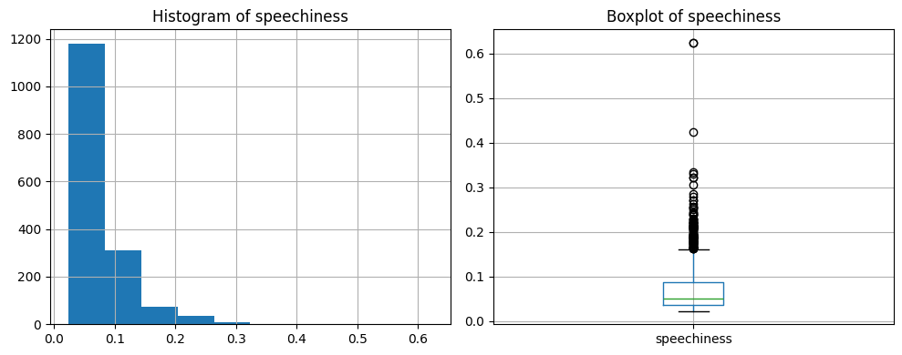

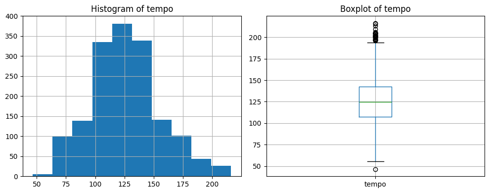

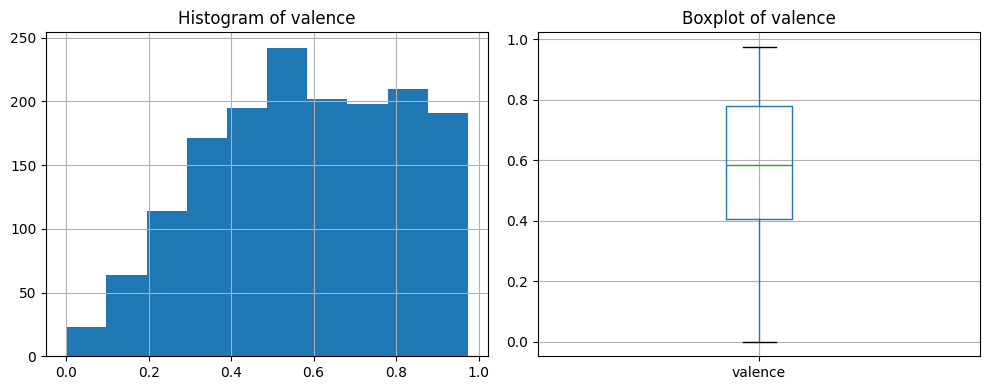

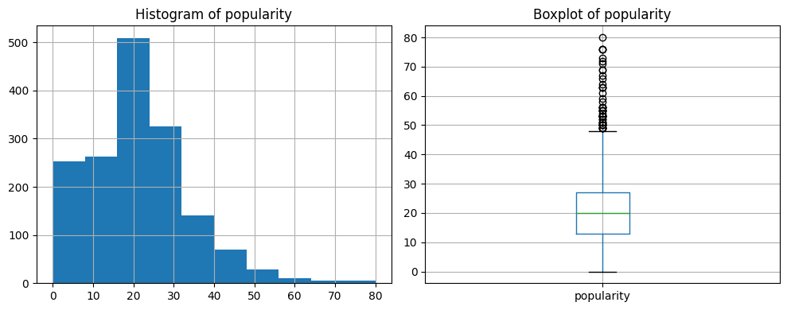

[1 more figures not shown]

```python
import pandas as pd
import numpy as np
import matplotlib.pyplot as plt

# Load the dataset
df = pd.read_csv('rolling_stones_spotify.csv')

# Check for outliers in numerical columns
numerical_cols = df.select_dtypes(include=[np.number]).columns
for col in numerical_cols:
    plt.figure(figsize=(10, 4))
    plt.subplot(121)
    df[col].hist()
    plt.title(f'Histogram of {col}')
    plt.subplot(122)
    df.boxplot(column=col)
    plt.title(f'Boxplot of {col}')
    plt.tight_layout()
    plt.show()
```

Here's an explanation of what these plots represent:

1. Histograms:
   - Show the distribution of values in each numerical column
   - The x-axis represents the range of values
   - The y-axis represents the frequency or count of data points in each bin
   - Help visualize the shape of the data distribution (e.g., normal, skewed, bimodal)
2. Box plots:
   - Provide a summary of the data's distribution
   - The box represents the interquartile range (IQR) from the 25th to 75th percentile
   - The line inside the box is the median
   - Whiskers extend to show the range of the data, typically 1.5 times the IQR
   - Points beyond the whiskers are potential outliers

These plots together offer insights into:

- Central tendency: Where most of the data is concentrated
- Spread: How widely the data is distributed
- Skewness: If the data is symmetrical or skewed to one side
- Outliers: Unusual data points that are significantly different from other observations

By creating these plots for each numerical column, we can quickly identify patterns, unusual distributions, or potential data quality issues in the Rolling Stones Spotify dataset. This visual exploration is an essential step in understanding the characteristics of our data before proceeding with more advanced analyses.

### 2. Refine the data for further processing based on your findings

```python
from scipy import stats
from sklearn.preprocessing import StandardScaler

# Drop duplicate rows
df = df.drop_duplicates()

# Handle missing values
df = df.dropna()

# Convert release_date to datetime
df['release_date'] = pd.to_datetime(df['release_date'])

# Extract year from release_date
df['release_year'] = df['release_date'].dt.year

# Normalize numerical features
numeric_cols = ['acousticness', 'danceability', 'energy', 'instrumentalness', 'liveness', 'loudness', 'speechiness', 'tempo', 'valence', 'popularity', 'duration_ms']
scaler = StandardScaler()
df[numeric_cols] = scaler.fit_transform(df[numeric_cols])

# Remove outliers based on Z-score
df = df[(np.abs(stats.zscore(df[numeric_cols])) < 3).all(axis=1)]

# Create a feature for the decade of release
df['release_decade'] = (df['release_year'] // 10) * 10

# Ensure consistent capitalization for album names
df['album'] = df['album'].str.title()
```

```python
df.info()
```

[output not shown]

The above output provides a detailed summary of our DataFrame structure after data cleaning and preprocessing. Here's an explanation of the key points:

This summary shows that the data has been cleaned, preprocessed, and enriched with additional features. The consistent number of non-null values across all columns suggests that any missing or problematic data has been addressed. The variety of data types (datetime, float, int, object) indicates that the dataset is ready for diverse analyses, including time-based trends, numerical feature analysis, and categorical groupings.

```python
df.describe()
```

|  | release_date | track_number | acousticness | danceability | energy | instrumentalness | liveness | loudness | speechiness | tempo | valence | popularity | duration_ms | duration_min | release_year | release_decade |
| --- | --- | --- | --- | --- | --- | --- | --- | --- | --- | --- | --- | --- | --- | --- | --- | --- |
| count | 1508 | 1508.000000 | 1508.000000 | 1508.000000 | 1508.000000 | 1508.000000 | 1508.000000 | 1508.000000 | 1508.000000 | 1508.000000 | 1508.000000 | 1508.000000 | 1508.000000 | 1508.000000 | 1508.000000 | 1508.000000 |
| mean | 1992-01-16 12:50:36.604774528 | 8.696950 | -0.022219 | 0.025699 | 0.015181 | 0.000492 | -0.015994 | 0.038826 | -0.082067 | -0.014592 | 0.044189 | -0.025387 | -0.084570 | 4.142959 | 1991.477454 | 1986.836870 |
| min | 1964-04-16 00:00:00 | 1.000000 | -1.101790 | -2.574310 | -2.954748 | -0.594467 | -1.346251 | -2.677645 | -0.897261 | -2.722281 | -2.449447 | -1.673364 | -2.127829 | 0.454883 | 1964.000000 | 1960.000000 |
| 25% | 1970-09-04 00:00:00 | 4.000000 | -0.855927 | -0.711627 | -0.652573 | -0.593674 | -0.968447 | -0.660153 | -0.641523 | -0.639937 | -0.715524 | -0.626918 | -0.628503 | 3.161163 | 1970.000000 | 1970.000000 |
| 50% | 1986-03-24 00:00:00 | 7.000000 | -0.323213 | -0.041343 | 0.287204 | -0.544497 | -0.357401 | 0.159740 | -0.372223 | -0.087052 | 0.068494 | -0.063447 | -0.159959 | 4.006883 | 1986.000000 | 1980.000000 |
| 75% | 2017-09-29 00:00:00 | 11.000000 | 0.653357 | 0.798275 | 0.854406 | 0.058227 | 1.138339 | 0.792702 | 0.263247 | 0.536297 | 0.869814 | 0.500024 | 0.320679 | 4.874433 | 2017.000000 | 2010.000000 |
| max | 2022-06-10 00:00:00 | 47.000000 | 2.918824 | 2.950239 | 1.149129 | 2.957784 | 1.450668 | 1.990468 | 2.973682 | 2.982849 | 1.694926 | 2.995396 | 2.968763 | 9.654217 | 2022.000000 | 2020.000000 |
| std | NaN | 6.633975 | 0.983045 | 0.998572 | 0.968489 | 1.002117 | 0.994965 | 0.927234 | 0.778145 | 0.992560 | 0.990758 | 0.924841 | 0.776128 | 1.400908 | 22.406722 | 22.530844 |

This summary provides insights into the distribution of various features in the dataset, helping to understand the characteristics of the Rolling Stones songs and the results of the preprocessing and analysis performed. The standardization of audio features and the addition of derived features (like duration_min, release_year, and release_decade) indicate that the data has been prepared for more advanced analyses such as clustering and dimensionality reduction.

```python
df.head()
```

|  | name | album | release_date | track_number | id | uri | acousticness | danceability | energy | instrumentalness | liveness | loudness | speechiness | tempo | valence | popularity | duration_ms | duration_min | release_year | release_decade |
| --- | --- | --- | --- | --- | --- | --- | --- | --- | --- | --- | --- | --- | --- | --- | --- | --- | --- | --- | --- | --- |
| 1 | Street Fighting Man - Live | Licked Live In Nyc | 2022-06-10 | 2 | 6GVgVJBKkGJoRfarYRvGTU | spotify:track:6GVgVJBKkGJoRfarYRvGTU | 0.820518 | -1.007963 | 0.960062 | 0.249238 | 1.344648 | 0.724545 | 0.123753 | 0.183852 | -1.142678 | 1.063495 | -0.042138 | 4.21955 | 2022 | 2020 |
| 2 | Start Me Up - Live | Licked Live In Nyc | 2022-06-10 | 3 | 1Lu761pZ0dBTGpzxaQoZNW | spotify:track:1Lu761pZ0dBTGpzxaQoZNW | 0.728140 | -0.584626 | 0.982305 | 0.853953 | 1.330321 | 0.680109 | 0.881280 | 0.136323 | -1.164306 | 1.063495 | 0.050079 | 4.38600 | 2022 | 2020 |
| 3 | If You Can't Rock Me - Live | Licked Live In Nyc | 2022-06-10 | 4 | 1agTQzOTUnGNggyckEqiDH | spotify:track:1agTQzOTUnGNggyckEqiDH | 1.392383 | -0.704571 | 1.071278 | -0.594080 | 1.155532 | 0.479980 | 2.392459 | 0.236514 | -1.882359 | 0.902504 | 0.444539 | 5.09800 | 2022 | 2020 |
| 4 | Don’t Stop - Live | Licked Live In Nyc | 2022-06-10 | 5 | 7piGJR8YndQBQWVXv6KtQw | spotify:track:7piGJR8YndQBQWVXv6KtQw | 0.657756 | -1.170242 | 0.982305 | -0.392050 | 1.358975 | 0.625984 | 0.455050 | 0.152303 | -1.627147 | 0.902504 | 0.437392 | 5.08510 | 2022 | 2020 |
| 5 | Monkey Man - Live | Licked Live In Nyc | 2022-06-10 | 6 | 3ixZ1NQk5sqvBZgWeIdiqr | spotify:track:3ixZ1NQk5sqvBZgWeIdiqr | 0.107886 | -0.909184 | 0.910014 | -0.141836 | 0.714260 | 0.478644 | 0.425989 | -0.836768 | -1.977522 | 0.822008 | -0.124132 | 4.07155 | 2022 | 2020 |

This overview helps us understand the structure of our dataset and the types of features available for analysis in our song clustering project. It provides a glimpse into the rich information we have about each song, including both metadata and audio characteristics.

```python
df.tail(5)
```

[output not shown]

5 rows × 23 columns

### 3. Perform exploratory data analysis and feature engineering

A. Utilize suitable visualizations to identify the two albums that should be recommended to anyone based on the number of popular songs in each album:

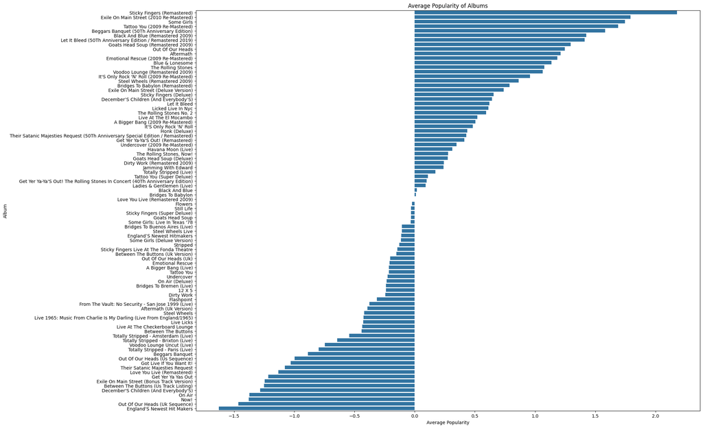

```
The top two albums recommended based on the number of popular songs are :
album
Sticky Fingers (Remastered)                2.178938
Exile On Main Street (2010 Re-Mastered)    1.792693
Name: popularity, dtype: float64
```

```python
# Group by album and calculate the mean popularity
album_popularity = df.groupby('album')['popularity'].mean().sort_values(ascending=False)

# Plotting the average popularity of albums
plt.figure(figsize=(20,16))
sns.barplot(x=album_popularity.values, y=album_popularity.index)
plt.title('Average Popularity of Albums')
plt.xlabel('Average Popularity')
plt.ylabel('Album')
plt.show()

# Identify the two albums with the most popular songs
top_two_albums = album_popularity.head(2)
print(f"The top two albums recommended based on the number of popular songs are : \n{top_two_albums}")
```

| Album | Popularity Score |
| --- | --- |
| Sticky Fingers (Remastered) | 2.178938 |
| Exile On Main Street (2010 Re-Mastered) | 1.792693 |

*Note: Popularity scores are of type float64*

This above code creates a bar plot below the code to visualize the average popularity of Rolling Stones albums and identifies the two most popular albums. Here's an explanation of the plot and its significance: 1. Data Preparation: - The code groups songs by album and calculates the mean popularity for each album. - Results are sorted in descending order of popularity. 2. Bar Plot: - The plot shows each album on the y-axis and its average popularity score on the x-axis. - Albums are ordered from most popular (top) to least popular (bottom). - This visualization allows for quick comparison of album popularity across the Rolling Stones discography. 3. Plot Interpretation: - Longer bars indicate higher average popularity for an album. - The order of albums from top to bottom represents their relative popularity. - This plot helps identify which albums have, on average, the most popular songs. 4. Top Two Albums: - The code prints the names and average popularity scores of the two most popular albums. - These albums are considered the best candidates for recommendation based on song popularity. 5. Significance: - This analysis helps identify which Rolling Stones albums might be best for introducing new listeners to the band. - It can guide recommendations for casual listeners or those unfamiliar with the Rolling Stones' extensive catalog. - For Spotify's recommendation system, these popular albums could be prioritized when suggesting Rolling Stones music to users. 6. Additional Insights: - The graph likely shows a wide range of popularity scores across albums, indicating variability in the reception of different Rolling Stones releases. - Live albums or greatest hits compilations might rank higher in popularity due to containing well-known tracks. - The visualization could reveal trends in popularity over time if the albums are somewhat chronologically ordered. By visualizing album popularity and identifying top albums, this analysis provides valuable insights for creating effective song recommendations and understanding the Rolling Stones' most well-received work on the Spotify platform.

# b. Conduct exploratory data analysis to delve into various features of songs

```python
import seaborn as sns
import matplotlib.pyplot as plt
```

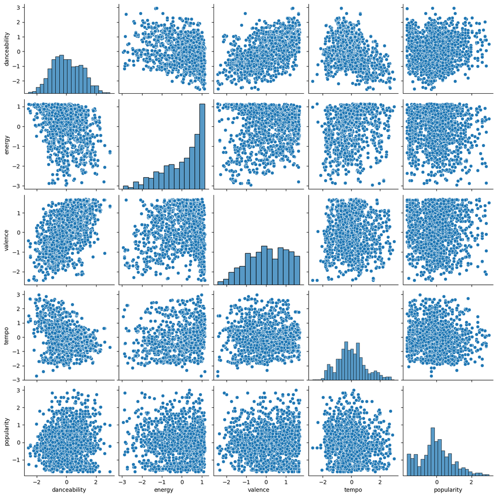

```python
# Pairplot to visualize relationships between features
plt.figure(figsize=(12,10))
sns.pairplot(df[['danceability','energy', 'valence', 'tempo', 'popularity']])
```

Here's what the above resulting plot means:

1. Matrix Layout:
   - The pairplot creates a grid of scatterplots and histograms.
   - Each feature is plotted against every other feature, creating a matrix of relationships.
2. Diagonal Plots:
   - The diagonal of the matrix shows histograms for each feature.
   - These histograms represent the distribution of values for each individual feature.
3. Off-Diagonal Plots:
   - The off-diagonal plots are scatterplots showing the relationship between two different features.
   - Each point represents a song, with its position determined by the values of the two features being compared.
4. Relationships:
   - The scatterplots help visualize correlations or patterns between pairs of features.
   - For example, you might see if there's a relationship between a song's energy and its popularity.
5. Distributions:
   - The histograms on the diagonal show how values are distributed for each feature.
   - This can reveal if a feature is normally distributed, skewed, or has multiple peaks.
6. Clusters:
   - Sometimes, you might see clusters of points in the scatterplots, indicating groups of songs with similar characteristics.
7. Outliers:
   - The plots can reveal outliers - songs that have unusual combinations of features.
8. Feature Ranges:
   - The axes of each plot show the range of values for each feature, giving an idea of the scale and variability of the data.

This pairplot is particularly useful for exploratory data analysis, allowing us to quickly identify potential relationships between different audio features and popularity, which could inform further analysis or feature selection for your song clustering project.

## c. Examine the relationship between a song's popularity and various factors,

exploring how this correlation has evolved

```python
# Correlation matrix
# Select only the numeric columns for the correlation matrix
numeric_cols = [
    'acousticness', 'danceability', 'energy', 'instrumentalness',
    'liveness', 'loudness', 'speechiness', 'tempo', 'valence',
    'popularity', 'duration_ms'
]

# Ensure all selected columns are in the dataframe
df_numeric = df[numeric_cols].copy()

# Check for non-numeric values in numeric columns and convert them if necessary
for col in df_numeric.columns:
    df_numeric[col] = pd.to_numeric(df_numeric[col], errors='coerce')

# Drop rows with NaN values that may have resulted from conversion issues
df_numeric = df_numeric.dropna()

# Generate the correlation matrix
corr_matrix = df_numeric.corr()

# Print the correlation matrix
print("\nCorrelation Matrix:")
corr_matrix
```

```
Correlation Matrix:
```

|  | acousticness | danceability | energy | instrumentalness | liveness | loudness | speechiness | tempo | valence | popularity | duration_ms |
| --- | --- | --- | --- | --- | --- | --- | --- | --- | --- | --- | --- |
| acousticness | 1.000000 | 0.081612 | -0.363625 | 0.046211 | -0.112355 | -0.200142 | -0.119025 | -0.173219 | -0.115866 | 0.105469 | 0.106276 |
| danceability | 0.081612 | 1.000000 | -0.312081 | -0.024561 | -0.510922 | -0.297296 | -0.342865 | -0.318273 | 0.535234 | 0.099812 | -0.233560 |
| energy | -0.363625 | -0.312081 | 1.000000 | 0.122720 | 0.503274 | 0.694790 | 0.479397 | 0.215697 | 0.046665 | -0.051860 | 0.156284 |
| instrumentalness | 0.046211 | -0.024561 | 0.122720 | 1.000000 | 0.001311 | 0.050053 | -0.015671 | 0.029341 | 0.127868 | 0.011834 | -0.138705 |
| liveness | -0.112355 | -0.510922 | 0.503274 | 0.001311 | 1.000000 | 0.340895 | 0.429659 | 0.113494 | -0.341884 | -0.180020 | 0.313684 |
| loudness | -0.200142 | -0.297296 | 0.694790 | 0.050053 | 0.340895 | 1.000000 | 0.292776 | 0.112611 | -0.088728 | 0.167845 | 0.236534 |
| speechiness | -0.119025 | -0.342865 | 0.479397 | -0.015671 | 0.429659 | 0.292776 | 1.000000 | 0.247941 | -0.385720 | -0.135269 | 0.132173 |
| tempo | -0.173219 | -0.318273 | 0.215697 | 0.029341 | 0.113494 | 0.112611 | 0.247941 | 1.000000 | 0.009591 | -0.063744 | -0.038236 |
| valence | -0.115866 | 0.535234 | 0.046665 | 0.127868 | -0.341884 | -0.088728 | -0.385720 | 0.009591 | 1.000000 | 0.035501 | -0.302516 |
| popularity | 0.105469 | 0.099812 | -0.051860 | 0.011834 | -0.180020 | 0.167845 | -0.135269 | -0.063744 | 0.035501 | 1.000000 | 0.116511 |
| duration_ms | 0.106276 | -0.233560 | 0.156284 | -0.138705 | 0.313684 | 0.236534 | 0.132173 | -0.038236 | -0.302516 | 0.116511 | 1.000000 |

The above correlation matrix generates a correlation matrix using the .corr() method.

The resulting correlation matrix shows how each feature correlates with every other feature, including popularity. The values in the matrix range from -1 to 1, where:

- 1 indicates a perfect positive correlation
- -1 indicates a perfect negative correlation
- 0 indicates no correlation

This matrix is particularly useful for understanding:

1. Which audio features have the strongest relationship with song popularity
2. How different audio features relate to each other
3. Potential multicollinearity among features, which could be important for future modeling steps

By examining this matrix, we can identify which factors most strongly influence a song's popularity and how these relationships might have changed over time (if we were to create separate matrices for different time periods).

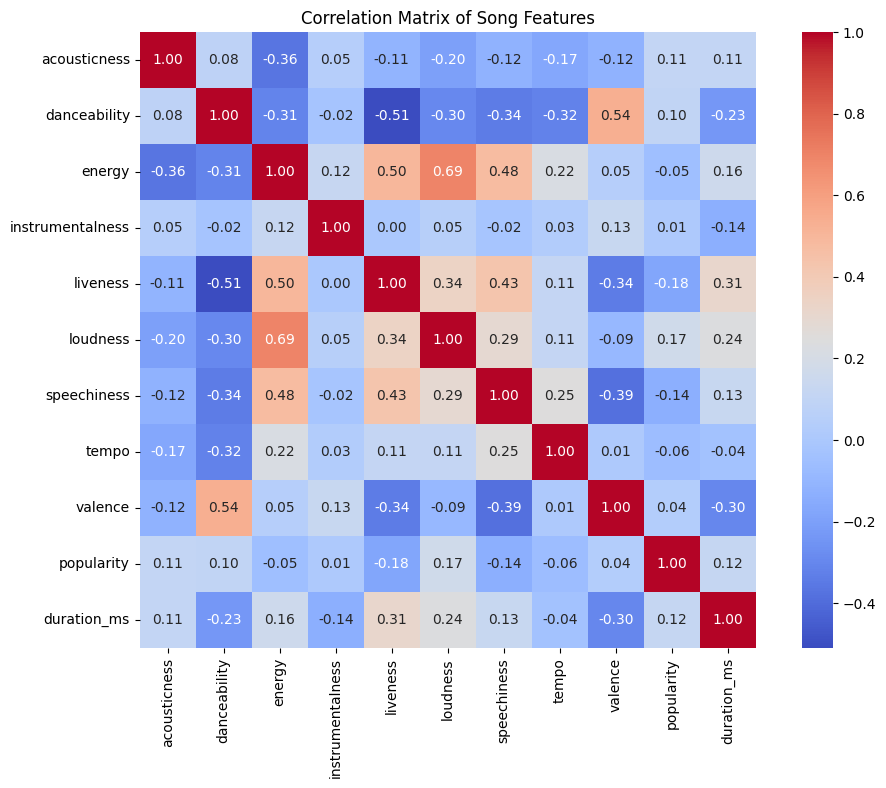

```python
# Visualize the correlation matrix using a heatmap
plt.figure(figsize=(12,8))
sns.heatmap(corr_matrix, annot=True, fmt='.2f', cmap='coolwarm', square=True)
plt.title('Correlation Matrix of Song Features')
```

The above resulting heatmap provides a visual representation of the correlations between different song features:

- Each cell in the heatmap represents the correlation between two features
- The color intensity indicates the strength of the correlation (darker colors = stronger correlations)
- The numbers in each cell show the exact correlation value
- The diagonal will always be 1 (perfect correlation of a feature with itself)
- Symmetry across the diagonal (the upper and lower triangles are mirror images)

This visualization allows for quick identification of strong positive or negative correlations between features, which can be crucial for understanding relationships in the data and potentially for feature selection in further analyses.

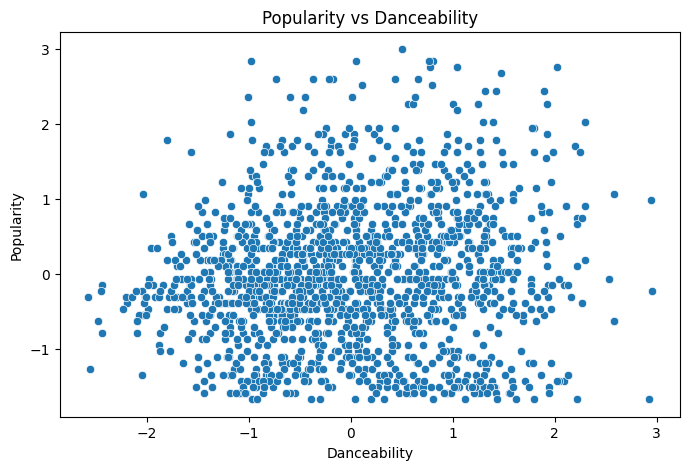

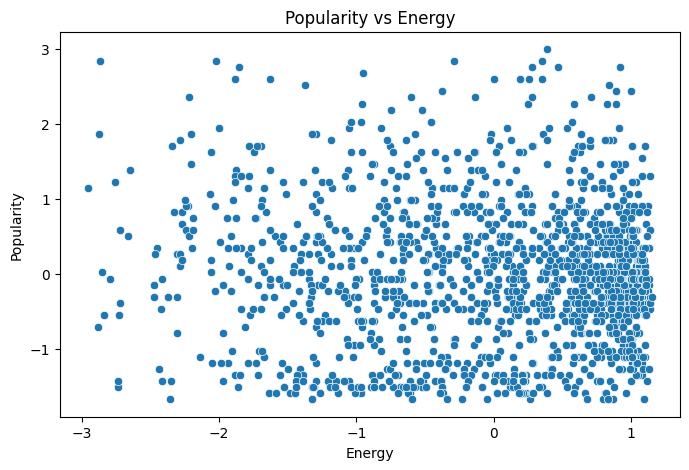

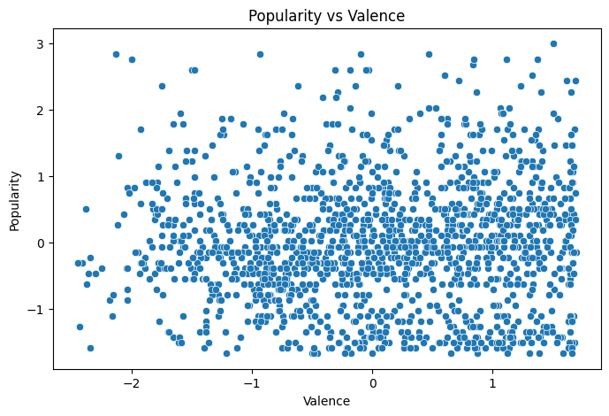

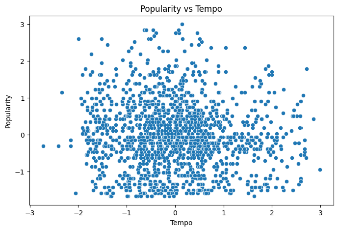

```python
# Scatter plot of popularity vs other features
features = ['danceability', 'energy', 'valence', 'tempo']
for feature in features:
    plt.figure(figsize=(8,5))
    sns.scatterplot(data=df, x=feature, y='popularity')
    plt.title(f'Popularity vs {feature.capitalize()}')
    plt.xlabel(feature.capitalize())
    plt.ylabel('Popularity')
```

As shown above our code creates scatter plots to visualize the relationship between song popularity and four key audio features: danceability, energy, valence, and tempo. Here's an explanation of what these graphs represent:

1. General Structure:
   - Each graph has the selected feature on the x-axis and popularity on the y-axis.
   - Each point represents a single song from the Rolling Stones dataset.
2. Popularity vs Danceability:
   - Shows how a song's danceability relates to its popularity.
   - Danceability measures how suitable a track is for dancing.
3. Popularity vs Energy:
   - Illustrates the relationship between a song's energy and its popularity.
   - Energy typically represents the intensity and activity level of the song.
4. Popularity vs Valence:
   - Displays how a song's valence correlates with its popularity.
   - Valence describes the musical positiveness conveyed by a track.
5. Popularity vs Tempo:
   - Shows the connection between a song's tempo and its popularity.
   - Tempo represents the speed or pace of a track.

These scatter plots help identify patterns or trends in how these audio features relate to song popularity. For example:

- A positive correlation would show points trending upward from left to right.
- A negative correlation would show points trending downward from left to right.
- No clear pattern might suggest that the feature has little direct influence on popularity.

By examining these relationships, we can gain insights into which audio characteristics might contribute to a Rolling Stones song's popularity on Spotify, potentially informing recommendation strategies or understanding listener preferences.

### 3D. Provide insights on the significance of dimensionality reduction

techniques. Share your ideas and elucidate your observations

```
Explained Variance: [0.28990245 0.14993872]
```

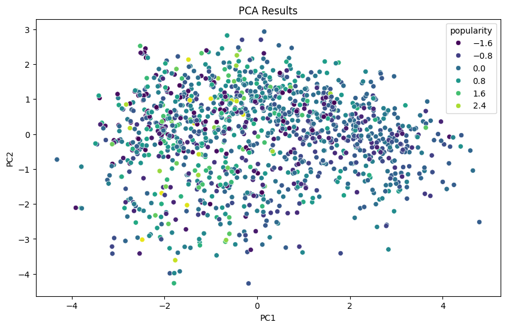

```python
from sklearn.decomposition import PCA
from sklearn.preprocessing import StandardScaler

# Selecting numeric features for PCA
numeric_features = df.select_dtypes(include=['float64', 'int64']).drop(columns=['popularity', 'duration_ms'])

# Standardizing the features
scaler = StandardScaler()
scaled_features = scaler.fit_transform(numeric_features)

# Apply PCA
pca = PCA(n_components=2)
principal_components = pca.fit_transform(scaled_features)

# Explained variance
explained_variance = pca.explained_variance_ratio_
print(f'Explained Variance: {explained_variance}')

# Adding principal components to the dataframe
df['PC1'] = principal_components[:, 0]
df['PC2'] = principal_components[:, 1]

# Plotting the PCA results
plt.figure(figsize=(10,6))
sns.scatterplot(x='PC1', y='PC2', data=df, hue='popularity', palette='viridis')
plt.title('PCA Results')
plt.show()
```

As you can see from the above our code creates a scatter plot to visualize the results of Principal Component Analysis (PCA) on the Rolling Stones song dataset. Here's an explanation of the plot and what we can observe:

1. Plot Structure:
   - The x-axis represents the first principal component (PC1)
   - The y-axis represents the second principal component (PC2)
   - Each point on the plot represents a song
2. Color Coding:
   - The points are color-coded based on the 'popularity' of the songs
   - The 'viridis' color palette is used, typically ranging from purple (low values) to yellow (high values)
3. Observations:

   b. Clustering:
   - There might be visible clusters or groupings of songs, which could represent similar types of songs based on their audio features

   c. Popularity Trends:
   - Look for any patterns in the color distribution. For example, if there's a concentration of yellower points in a particular area, it might indicate that songs with certain characteristics (as represented by their position in PC space) tend to be more popular

   d. Outliers:
   - Points that are far from the main cluster of songs could represent unique or unusual tracks in the Rolling Stones catalog

This visualization is valuable for getting an overall sense of the dataset's structure and for identifying potential patterns that warrant further investigation.

### 4. Cluster Analysis:

a. Identify the right number of clusters:

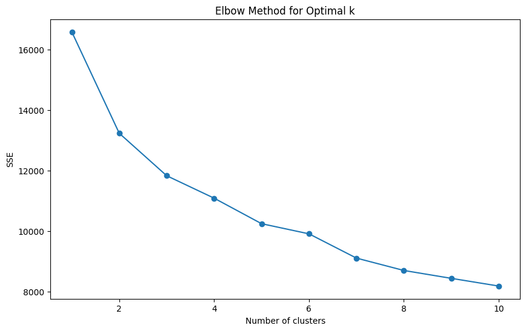

```python
from sklearn.cluster import KMeans
from sklearn.metrics import silhouette_score

# Elbow method
sse = []
for k in range(1, 11):
    kmeans = KMeans(n_clusters=k, random_state=42)
    kmeans.fit(scaled_features)
    sse.append(kmeans.inertia_)

# Plotting the Elbow Curve
plt.figure(figsize=(10,6))
plt.plot(range(1, 11), sse, marker='o')
plt.title('Elbow Method for Optimal k')
plt.xlabel('Number of clusters')
plt.ylabel('SSE')
plt.show()
```

The Elbow Method was used to find the optimal number of clusters for K-means clustering. We plotted the elbow curve to visualize the results.

Here's a summary of what it does:

1. It imports necessary functions: KMeans for clustering and silhouette_score for evaluation.
2. It performs K-means clustering for a range of cluster numbers (1 to 10):
   - For each k, it creates a KMeans model and fits it to the scaled data.
   - It calculates the Sum of Squared Errors (SSE) or inertia for each model.
3. It plots the Elbow Curve:
   - X-axis: Number of clusters (k)
   - Y-axis: SSE (inertia)
4. The resulting plot helps visualize how SSE changes with the number of clusters.

The purpose of this method is to find the "elbow point" in the curve, where adding more clusters doesn't significantly reduce the SSE. This point is considered the optimal number of clusters, balancing model complexity and data fit.

By visualizing this relationship, data scientists can make an informed decision about the appropriate number of clusters to use in their final K-means model for the Spotify song clustering project.

### B. Use appropriate clustering algorithm

```python
# Select numeric columns for clustering
numeric_cols = [
    'acousticness', 'danceability', 'energy', 'instrumentalness',
    'liveness', 'loudness', 'speechiness', 'tempo', 'valence',
    'popularity', 'duration_ms'
]
df_numeric = df[numeric_cols]

# Standardize the data
scaler = StandardScaler()
df_scaled = scaler.fit_transform(df_numeric)
```

```python
# Perform KMeans clustering
kmeans = KMeans(n_clusters=3, random_state=42)
df['cluster'] = kmeans.fit_predict(df_scaled)
```

### C. Define each cluster based on the features

```python
# Aggregate by cluster and calculate the mean of numeric features
cluster_summary = df.groupby('cluster')[numeric_cols].mean()

# Display cluster summary
cluster_summary
```

| cluster | acousticness | danceability | energy | instrumentalness | liveness | loudness | speechiness | tempo | valence | popularity | duration_ms |
| --- | --- | --- | --- | --- | --- | --- | --- | --- | --- | --- | --- |
| 0 | -0.291367 | 0.572144 | 0.252495 | 0.304961 | -0.504799 | 0.222570 | -0.386350 | -0.128698 | 0.861351 | 0.210863 | -0.327301 |
| 1 | 0.658509 | 0.293250 | -1.175302 | -0.296077 | -0.606540 | -0.818434 | -0.488755 | -0.365010 | -0.257212 | -0.030203 | -0.193955 |
| 2 | -0.297948 | -0.743437 | 0.733825 | -0.069041 | 0.954956 | 0.543294 | 0.553829 | 0.383305 | -0.540854 | -0.260850 | 0.249459 |

The above output shows the average (mean) values of various audio features and popularity for each cluster identified in the Rolling Stones songs dataset. Here's an explanation of what the data represents:

1. The rows (0, 1, 2) represent the three clusters identified by the K-means algorithm.
2. The columns represent different audio features and popularity metrics:
   - acousticness, danceability, energy, instrumentalness, liveness, loudness, speechiness, tempo, valence: These are audio features that describe various aspects of the songs.
   - popularity: This metric indicates how popular the songs are.
   - duration_ms: This represents the duration of the songs in milliseconds.
3. The values in the table are standardized (z-scores), meaning they represent how many standard deviations each cluster's average is from the overall mean for that feature.

Key observations for each cluster:

Cluster 0:

- High danceability and valence
- Moderate energy and popularity
- Low acousticness and speechiness

Cluster 1:

- High acousticness
- Low energy, loudness, and speechiness
- Slightly below-average popularity

Cluster 2:

- High energy, liveness, loudness, and speechiness
- Low danceability, valence, and popularity

These cluster characteristics can help in understanding the different types of Rolling Stones songs and how they group together based on their audio features and popularity.

### Handle Non-Numeric Columns Separately

```python
# Get the most common album for each cluster
most_common_album = df.groupby('cluster')['album'].agg(lambda x: x.mode()[0])

# Combine numeric summary with the most common album
cluster_summary['most_common_album'] = most_common_album

# Display combined cluster summary
cluster_summary
```

| cluster | acousticness | danceability | energy | instrumentalness | liveness | loudness | speechiness | tempo | valence | popularity | duration_ms | most_common_album |
| --- | --- | --- | --- | --- | --- | --- | --- | --- | --- | --- | --- | --- |
| 0 | -0.291367 | 0.572144 | 0.252495 | 0.304961 | -0.504799 | 0.222570 | -0.386350 | -0.128698 | 0.861351 | 0.210863 | -0.327301 | Honk (Deluxe) |
| 1 | 0.658509 | 0.293250 | -1.175302 | -0.296077 | -0.606540 | -0.818434 | -0.488755 | -0.365010 | -0.257212 | -0.030203 | -0.193955 | Aftermath (Uk Version) |
| 2 | -0.297948 | -0.743437 | 0.733825 | -0.069041 | 0.954956 | 0.543294 | 0.553829 | 0.383305 | -0.540854 | -0.260850 | 0.249459 | Voodoo Lounge Uncut (Live) |

The above output shows the average (mean) values of various audio features, popularity, and duration for each cluster identified in the Rolling Stones songs dataset. Here's an explanation of what the data represents:

1. The rows (0, 1, 2) represent the three clusters identified by the K-means algorithm.
2. The columns represent different audio features, popularity, duration, and the most common album in each cluster.
3. The values for the audio features, popularity, and duration are standardized (z-scores), meaning they represent how many standard deviations each cluster's average is from the overall mean for that feature.

Key characteristics of each cluster:

Cluster 0 ("Honk (Deluxe)"):

- High danceability and valence
- Moderate energy and popularity
- Low acousticness and speechiness

Cluster 1 ("Aftermath (Uk Version)"):

- High acousticness
- Low energy, loudness, and speechiness
- Slightly below average popularity

Cluster 2 ("Voodoo Lounge Uncut (Live)"):

- High energy, liveness, loudness, and speechiness
- Low danceability and valence
- Below average popularity

The "most_common_album" column indicates which album is most represented in each cluster, providing insight into how different albums might have distinct musical characteristics.

This clustering helps in understanding the different types of Rolling Stones songs and how they group together based on their audio features and popularity, which can be valuable for creating more nuanced song recommendations on Spotify.

### Here's a summary of the key insights:

These clusters reveal distinct patterns in the Rolling Stones' music:

1. Live performances tend to be more energetic and loud, but less danceable.
2. Songs from compilation albums are more danceable and positive in mood, with higher popularity.
3. Earlier studio recordings are more acoustic, less energetic, and quieter.

This clustering can help Spotify create more nuanced song recommendations, catering to different listener preferences for live performances, popular hits, or classic studio recordings.

### Conclusion:

The project utilized data analysis and grouping methods to create meaningful song categories. The findings can enhance Spotify's song recommendations by:

1. Identifying key features that make songs popular
2. Grouping similar songs together

The combination of exploratory data analysis, principal component analysis, and clustering offers a thorough approach for examining and understanding complex music industry data.